# Risk Factor Analysis

## Outcome Variable

**Outcome Variable:** stunted

## Predictor Variables

**Intervention Variable:** tr

**Adjustment Set:**

unadjusted

## Stratifying Variables

The analysis was stratified on these variable(s):

- impsan
- agecat
- studyid
- country

## Data Summary

| impsan | agecat | studyid | country | tr | stunted | n_cell | n |
| --- | --- | --- | --- | --- | --- | --- | --- |
| 0 | 24 months | ki1000110-WASH-Bangladesh | BANGLADESH | Control | 0 | 64 | 488 |
| 0 | 24 months | ki1000110-WASH-Bangladesh | BANGLADESH | Control | 1 | 55 | 488 |
| 0 | 24 months | ki1000110-WASH-Bangladesh | BANGLADESH | LNS | 0 | 73 | 488 |
| 0 | 24 months | ki1000110-WASH-Bangladesh | BANGLADESH | LNS | 1 | 51 | 488 |
| 0 | 24 months | ki1000110-WASH-Bangladesh | BANGLADESH | Other | 0 | 137 | 488 |
| 0 | 24 months | ki1000110-WASH-Bangladesh | BANGLADESH | Other | 1 | 108 | 488 |
| 1 | 24 months | ki1000110-WASH-Bangladesh | BANGLADESH | Control | 0 | 87 | 651 |
| 1 | 24 months | ki1000110-WASH-Bangladesh | BANGLADESH | Control | 1 | 55 | 651 |
| 1 | 24 months | ki1000110-WASH-Bangladesh | BANGLADESH | LNS | 0 | 111 | 651 |
| 1 | 24 months | ki1000110-WASH-Bangladesh | BANGLADESH | LNS | 1 | 57 | 651 |
| 1 | 24 months | ki1000110-WASH-Bangladesh | BANGLADESH | Other | 0 | 211 | 651 |
| 1 | 24 months | ki1000110-WASH-Bangladesh | BANGLADESH | Other | 1 | 130 | 651 |
| 1 | 6 months | ki1000110-WASH-Bangladesh | BANGLADESH | Control | 0 | 78 | 320 |
| 1 | 6 months | ki1000110-WASH-Bangladesh | BANGLADESH | Control | 1 | 14 | 320 |
| 1 | 6 months | ki1000110-WASH-Bangladesh | BANGLADESH | LNS | 0 | 76 | 320 |
| 1 | 6 months | ki1000110-WASH-Bangladesh | BANGLADESH | LNS | 1 | 12 | 320 |
| 1 | 6 months | ki1000110-WASH-Bangladesh | BANGLADESH | Other | 0 | 122 | 320 |
| 1 | 6 months | ki1000110-WASH-Bangladesh | BANGLADESH | Other | 1 | 18 | 320 |
| 0 | 6 months | ki1000110-WASH-Bangladesh | BANGLADESH | Control | 0 | 44 | 318 |
| 0 | 6 months | ki1000110-WASH-Bangladesh | BANGLADESH | Control | 1 | 13 | 318 |
| 0 | 6 months | ki1000110-WASH-Bangladesh | BANGLADESH | LNS | 0 | 74 | 318 |
| 0 | 6 months | ki1000110-WASH-Bangladesh | BANGLADESH | LNS | 1 | 16 | 318 |
| 0 | 6 months | ki1000110-WASH-Bangladesh | BANGLADESH | Other | 0 | 151 | 318 |
| 0 | 6 months | ki1000110-WASH-Bangladesh | BANGLADESH | Other | 1 | 20 | 318 |
| 0 | 24 months | ki1000111-WASH-Kenya | KENYA | Control | 0 | 204 | 810 |
| 0 | 24 months | ki1000111-WASH-Kenya | KENYA | Control | 1 | 106 | 810 |
| 0 | 24 months | ki1000111-WASH-Kenya | KENYA | LNS | 0 | 105 | 810 |
| 0 | 24 months | ki1000111-WASH-Kenya | KENYA | LNS | 1 | 53 | 810 |
| 0 | 24 months | ki1000111-WASH-Kenya | KENYA | Other | 0 | 230 | 810 |
| 0 | 24 months | ki1000111-WASH-Kenya | KENYA | Other | 1 | 112 | 810 |

[output cut: 223 more lines]

The following strata were considered:

- impsan: 0, agecat: 24 months, studyid: iLiNS_DYADM_LNS, country: MALAWI
- impsan: 0, agecat: 24 months, studyid: ki1000110-WASH-Bangladesh, country: BANGLADESH
- impsan: 0, agecat: 24 months, studyid: ki1000111-WASH-Kenya, country: KENYA
- impsan: 0, agecat: 24 months, studyid: ki1000304-ZnMort, country: INDIA
- impsan: 0, agecat: 24 months, studyid: ki1112895-Burkina Faso Zn, country: BURKINA FASO
- impsan: 0, agecat: 24 months, studyid: ki1135781-COHORTS, country: GUATEMALA
- impsan: 0, agecat: 24 months, studyid: ki1148112-iLiNS-DOSE, country: MALAWI
- impsan: 0, agecat: 24 months, studyid: ki1148112-iLiNS-DYAD-M, country: MALAWI
- impsan: 0, agecat: 24 months, studyid: ki1148112-LCNI-5, country: MALAWI
- impsan: 0, agecat: 24 months, studyid: kiGH5241-JiVitA-3, country: BANGLADESH
- impsan: 0, agecat: 24 months, studyid: kiGH5241-JiVitA-4, country: BANGLADESH
- impsan: 0, agecat: 6 months, studyid: iLiNS_DYADM_LNS, country: MALAWI
- impsan: 0, agecat: 6 months, studyid: ki1000110-WASH-Bangladesh, country: BANGLADESH
- impsan: 0, agecat: 6 months, studyid: ki1000111-WASH-Kenya, country: KENYA
- impsan: 0, agecat: 6 months, studyid: ki1000125-AgaKhanUniv, country: PAKISTAN
- impsan: 0, agecat: 6 months, studyid: ki1000304-VITAMIN-A, country: INDIA
- impsan: 0, agecat: 6 months, studyid: ki1000304-ZnMort, country: INDIA
- impsan: 0, agecat: 6 months, studyid: ki1017093b-PROVIDE, country: BANGLADESH
- impsan: 0, agecat: 6 months, studyid: ki1112895-Burkina Faso Zn, country: BURKINA FASO
- impsan: 0, agecat: 6 months, studyid: ki1135781-COHORTS, country: GUATEMALA
- impsan: 0, agecat: 6 months, studyid: ki1148112-iLiNS-DOSE, country: MALAWI
- impsan: 0, agecat: 6 months, studyid: ki1148112-iLiNS-DYAD-M, country: MALAWI
- impsan: 0, agecat: 6 months, studyid: ki1148112-LCNI-5, country: MALAWI
- impsan: 0, agecat: 6 months, studyid: kiGH5241-JiVitA-3, country: BANGLADESH
- impsan: 0, agecat: 6 months, studyid: kiGH5241-JiVitA-4, country: BANGLADESH
- impsan: 0, agecat: Birth, studyid: iLiNS_DYADM_LNS, country: MALAWI
- impsan: 0, agecat: Birth, studyid: ki1000125-AgaKhanUniv, country: PAKISTAN
- impsan: 0, agecat: Birth, studyid: ki1135781-COHORTS, country: GUATEMALA
- impsan: 0, agecat: Birth, studyid: ki1148112-iLiNS-DYAD-M, country: MALAWI
- impsan: 0, agecat: Birth, studyid: kiGH5241-JiVitA-3, country: BANGLADESH
- impsan: 0, agecat: Birth, studyid: kiGH5241-JiVitA-4, country: BANGLADESH
- impsan: 1, agecat: 24 months, studyid: iLiNS_DYADM_LNS, country: MALAWI
- impsan: 1, agecat: 24 months, studyid: ki1000110-WASH-Bangladesh, country: BANGLADESH
- impsan: 1, agecat: 24 months, studyid: ki1000111-WASH-Kenya, country: KENYA
- impsan: 1, agecat: 24 months, studyid: ki1000125-AgaKhanUniv, country: PAKISTAN
- impsan: 1, agecat: 24 months, studyid: ki1000304-ZnMort, country: INDIA
- impsan: 1, agecat: 24 months, studyid: ki1017093b-PROVIDE, country: BANGLADESH
- impsan: 1, agecat: 24 months, studyid: ki1112895-Burkina Faso Zn, country: BURKINA FASO
- impsan: 1, agecat: 24 months, studyid: ki1135781-COHORTS, country: GUATEMALA
- impsan: 1, agecat: 24 months, studyid: ki1148112-iLiNS-DOSE, country: MALAWI
- impsan: 1, agecat: 24 months, studyid: ki1148112-iLiNS-DYAD-M, country: MALAWI
- impsan: 1, agecat: 24 months, studyid: ki1148112-LCNI-5, country: MALAWI
- impsan: 1, agecat: 24 months, studyid: kiGH5241-JiVitA-3, country: BANGLADESH
- impsan: 1, agecat: 24 months, studyid: kiGH5241-JiVitA-4, country: BANGLADESH
- impsan: 1, agecat: 6 months, studyid: iLiNS_DYADM_LNS, country: MALAWI
- impsan: 1, agecat: 6 months, studyid: ki1000110-WASH-Bangladesh, country: BANGLADESH
- impsan: 1, agecat: 6 months, studyid: ki1000111-WASH-Kenya, country: KENYA
- impsan: 1, agecat: 6 months, studyid: ki1000125-AgaKhanUniv, country: PAKISTAN
- impsan: 1, agecat: 6 months, studyid: ki1000304-VITAMIN-A, country: INDIA
- impsan: 1, agecat: 6 months, studyid: ki1000304-ZnMort, country: INDIA
- impsan: 1, agecat: 6 months, studyid: ki1017093b-PROVIDE, country: BANGLADESH
- impsan: 1, agecat: 6 months, studyid: ki1112895-Burkina Faso Zn, country: BURKINA FASO
- impsan: 1, agecat: 6 months, studyid: ki1135781-COHORTS, country: GUATEMALA
- impsan: 1, agecat: 6 months, studyid: ki1148112-iLiNS-DOSE, country: MALAWI
- impsan: 1, agecat: 6 months, studyid: ki1148112-iLiNS-DYAD-M, country: MALAWI
- impsan: 1, agecat: 6 months, studyid: ki1148112-LCNI-5, country: MALAWI
- impsan: 1, agecat: 6 months, studyid: kiGH5241-JiVitA-3, country: BANGLADESH
- impsan: 1, agecat: 6 months, studyid: kiGH5241-JiVitA-4, country: BANGLADESH
- impsan: 1, agecat: Birth, studyid: ki1000125-AgaKhanUniv, country: PAKISTAN
- impsan: 1, agecat: Birth, studyid: ki1135781-COHORTS, country: GUATEMALA
- impsan: 1, agecat: Birth, studyid: kiGH5241-JiVitA-3, country: BANGLADESH
- impsan: 1, agecat: Birth, studyid: kiGH5241-JiVitA-4, country: BANGLADESH

### Dropped Strata

Some strata were dropped due to rare outcomes:

- impsan: 1, agecat: 6 months, studyid: ki1000111-WASH-Kenya, country: KENYA
- impsan: 0, agecat: 6 months, studyid: ki1000111-WASH-Kenya, country: KENYA
- impsan: 1, agecat: 6 months, studyid: ki1000125-AgaKhanUniv, country: PAKISTAN
- impsan: 1, agecat: 24 months, studyid: ki1000125-AgaKhanUniv, country: PAKISTAN
- impsan: 0, agecat: Birth, studyid: ki1000125-AgaKhanUniv, country: PAKISTAN
- impsan: 1, agecat: Birth, studyid: ki1000125-AgaKhanUniv, country: PAKISTAN
- impsan: 0, agecat: 24 months, studyid: ki1000304-ZnMort, country: INDIA
- impsan: 1, agecat: 6 months, studyid: ki1017093b-PROVIDE, country: BANGLADESH
- impsan: 0, agecat: 6 months, studyid: ki1017093b-PROVIDE, country: BANGLADESH
- impsan: 1, agecat: 24 months, studyid: ki1017093b-PROVIDE, country: BANGLADESH
- impsan: 1, agecat: 6 months, studyid: ki1112895-Burkina Faso Zn, country: BURKINA FASO
- impsan: 1, agecat: Birth, studyid: ki1135781-COHORTS, country: GUATEMALA
- impsan: 1, agecat: 24 months, studyid: ki1135781-COHORTS, country: GUATEMALA
- impsan: 1, agecat: 6 months, studyid: ki1148112-iLiNS-DOSE, country: MALAWI
- impsan: 1, agecat: 24 months, studyid: ki1148112-iLiNS-DOSE, country: MALAWI
- impsan: 0, agecat: Birth, studyid: ki1148112-iLiNS-DYAD-M, country: MALAWI
- impsan: 1, agecat: 24 months, studyid: ki1148112-iLiNS-DYAD-M, country: MALAWI
- impsan: 1, agecat: 6 months, studyid: ki1148112-LCNI-5, country: MALAWI
- impsan: 1, agecat: 24 months, studyid: ki1148112-LCNI-5, country: MALAWI
- impsan: 0, agecat: 24 months, studyid: kiGH5241-JiVitA-3, country: BANGLADESH
- impsan: 0, agecat: Birth, studyid: iLiNS_DYADM_LNS, country: MALAWI
- impsan: 1, agecat: 6 months, studyid: iLiNS_DYADM_LNS, country: MALAWI
- impsan: 1, agecat: 24 months, studyid: iLiNS_DYADM_LNS, country: MALAWI

## Methods Detail

We’re interested in the causal parameters $E[Y_a]$ for all values of $a \in \mathcal{A}$. These parameters represent the mean outcome if, possibly contrary to fact, we intervened to set all units to have $A=a$. Under the randomization and positivity assumptions, these are identified by the statistical parameters $\psi_a=E_W[E_{Y|A,W}(Y|A=a,W)]$. In addition, we’re interested in the mean of $Y$, $E[Y]$ under no intervention (the observed mean). We will estimate these parameters by using SuperLearner to fit the relevant likelihood factors – $E_{Y|A,W}(Y|A=a,W)$ and $p(A=a|W)$, and then updating our likelihood fit using a joint TMLE.

For unadjusted analyses ($W=\{\}$), initial likelihoods were estimated using Lrnr_glm to estimate the simple $E(Y|A)$ and Lrnr_mean to estimate $p(A)$. For adjusted analyses, a small library containing Lrnr_glmnet, Lrnr_xgboost, and Lrnr_mean was used.

Having estimated these parameters, we will then use the delta method to estimate relative risks and attributable risks relative to a prespecified baseline level of $A$.

[output not shown]

# Results Detail

## Results Plots

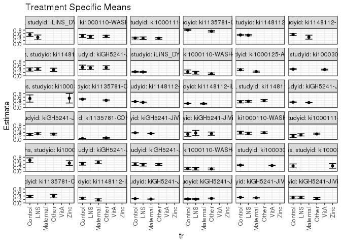

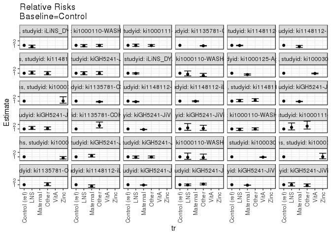

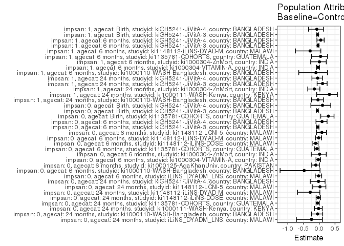

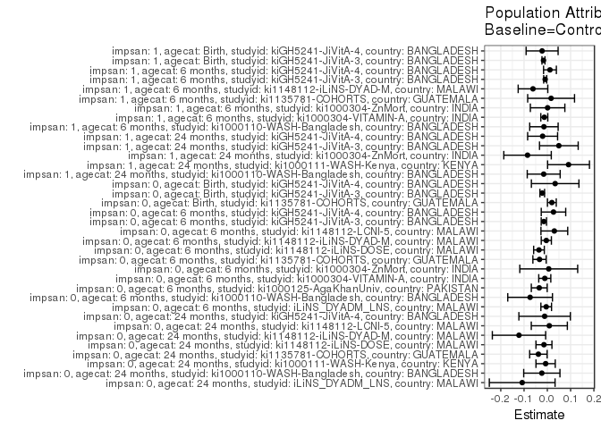

## Results Table

### Parameter: TSM

| impsan | agecat | studyid | country | intervention_level | baseline_level | estimate | ci_lower | ci_upper |
| --- | --- | --- | --- | --- | --- | --- | --- | --- |
| 0 | Birth | ki1135781-COHORTS | GUATEMALA | Control | NA | 0.0478469 | 0.0342714 | 0.0614223 |
| 0 | Birth | ki1135781-COHORTS | GUATEMALA | Other | NA | 0.0843882 | 0.0655616 | 0.1032148 |
| 0 | Birth | kiGH5241-JiVitA-3 | BANGLADESH | Control | NA | 0.3773465 | 0.3668655 | 0.3878275 |
| 0 | Birth | kiGH5241-JiVitA-3 | BANGLADESH | Maternal | NA | 0.3344574 | 0.3247005 | 0.3442142 |
| 0 | Birth | kiGH5241-JiVitA-4 | BANGLADESH | Control | NA | 0.2950820 | 0.1777592 | 0.4124048 |
| 0 | Birth | kiGH5241-JiVitA-4 | BANGLADESH | LNS | NA | 0.3653846 | 0.2143412 | 0.5164280 |
| 0 | Birth | kiGH5241-JiVitA-4 | BANGLADESH | Other | NA | 0.3300971 | 0.2367255 | 0.4234687 |
| 0 | 6 months | iLiNS_DYADM_LNS | MALAWI | Control | NA | 0.2310127 | 0.2072700 | 0.2547553 |
| 0 | 6 months | iLiNS_DYADM_LNS | MALAWI | LNS | NA | 0.2211221 | 0.1982303 | 0.2440139 |
| 0 | 6 months | ki1000110-WASH-Bangladesh | BANGLADESH | Control | NA | 0.2280702 | 0.1189719 | 0.3371684 |
| 0 | 6 months | ki1000110-WASH-Bangladesh | BANGLADESH | LNS | NA | 0.1777778 | 0.0986655 | 0.2568901 |
| 0 | 6 months | ki1000110-WASH-Bangladesh | BANGLADESH | Other | NA | 0.1169591 | 0.0687153 | 0.1652028 |
| 0 | 6 months | ki1000125-AgaKhanUniv | PAKISTAN | Control | NA | 0.3475177 | 0.2948700 | 0.4001655 |
| 0 | 6 months | ki1000125-AgaKhanUniv | PAKISTAN | Maternal | NA | 0.2428571 | 0.2094522 | 0.2762621 |
| 0 | 6 months | ki1000304-VITAMIN-A | INDIA | Control | NA | 0.3818182 | 0.3543831 | 0.4092533 |
| 0 | 6 months | ki1000304-VITAMIN-A | INDIA | VitA | NA | 0.3588040 | 0.3329355 | 0.3846724 |
| 0 | 6 months | ki1000304-ZnMort | INDIA | Control | NA | 0.5217391 | 0.3146961 | 0.7287821 |
| 0 | 6 months | ki1000304-ZnMort | INDIA | Zinc | NA | 0.5384615 | 0.2636247 | 0.8132984 |
| 0 | 6 months | ki1135781-COHORTS | GUATEMALA | Control | NA | 0.4827586 | 0.4540272 | 0.5114900 |
| 0 | 6 months | ki1135781-COHORTS | GUATEMALA | Other | NA | 0.4158076 | 0.3874207 | 0.4441944 |
| 0 | 6 months | ki1148112-iLiNS-DOSE | MALAWI | Control | NA | 0.3425926 | 0.3318917 | 0.3532935 |
| 0 | 6 months | ki1148112-iLiNS-DOSE | MALAWI | LNS | NA | 0.2994350 | 0.2765356 | 0.3223345 |
| 0 | 6 months | ki1148112-iLiNS-DYAD-M | MALAWI | Control | NA | 0.2310127 | 0.2152310 | 0.2467943 |
| 0 | 6 months | ki1148112-iLiNS-DYAD-M | MALAWI | Maternal | NA | 0.2243902 | 0.2025985 | 0.2461820 |
| 0 | 6 months | ki1148112-LCNI-5 | MALAWI | Control | NA | 0.3333333 | 0.2676314 | 0.3990352 |
| 0 | 6 months | ki1148112-LCNI-5 | MALAWI | LNS | NA | 0.3602941 | 0.3136813 | 0.4069069 |
| 0 | 6 months | ki1148112-LCNI-5 | MALAWI | Other | NA | 0.3990148 | 0.3316093 | 0.4664202 |
| 0 | 6 months | kiGH5241-JiVitA-3 | BANGLADESH | Control | NA | 0.3145196 | 0.3022141 | 0.3268251 |
| 0 | 6 months | kiGH5241-JiVitA-3 | BANGLADESH | Maternal | NA | 0.2852432 | 0.2739903 | 0.2964961 |
| 0 | 6 months | kiGH5241-JiVitA-4 | BANGLADESH | Control | NA | 0.2739726 | 0.2138826 | 0.3340626 |

[output cut: 56 more lines]

### Parameter: E(Y)

| impsan | agecat | studyid | country | intervention_level | baseline_level | estimate | ci_lower | ci_upper |
| --- | --- | --- | --- | --- | --- | --- | --- | --- |
| 0 | Birth | ki1135781-COHORTS | GUATEMALA | NA | NA | 0.0672646 | 0.0439922 | 0.0905369 |
| 0 | Birth | kiGH5241-JiVitA-3 | BANGLADESH | NA | NA | 0.3555035 | 0.3410663 | 0.3699408 |
| 0 | Birth | kiGH5241-JiVitA-4 | BANGLADESH | NA | NA | 0.3287037 | 0.2622544 | 0.3951530 |
| 0 | 6 months | iLiNS_DYADM_LNS | MALAWI | NA | NA | 0.2261712 | 0.1931879 | 0.2591546 |
| 0 | 6 months | ki1000110-WASH-Bangladesh | BANGLADESH | NA | NA | 0.1540881 | 0.1143446 | 0.1938315 |
| 0 | 6 months | ki1000125-AgaKhanUniv | PAKISTAN | NA | NA | 0.3127962 | 0.2500898 | 0.3755026 |
| 0 | 6 months | ki1000304-VITAMIN-A | INDIA | NA | NA | 0.3708399 | 0.3331217 | 0.4085582 |
| 0 | 6 months | ki1000304-ZnMort | INDIA | NA | NA | 0.5277778 | 0.3623864 | 0.6931691 |
| 0 | 6 months | ki1135781-COHORTS | GUATEMALA | NA | NA | 0.4492255 | 0.4087443 | 0.4897067 |
| 0 | 6 months | ki1148112-iLiNS-DOSE | MALAWI | NA | NA | 0.3067293 | 0.2814374 | 0.3320212 |
| 0 | 6 months | ki1148112-iLiNS-DYAD-M | MALAWI | NA | NA | 0.2266380 | 0.1997311 | 0.2535450 |
| 0 | 6 months | ki1148112-LCNI-5 | MALAWI | NA | NA | 0.3634116 | 0.3302473 | 0.3965759 |
| 0 | 6 months | kiGH5241-JiVitA-3 | BANGLADESH | NA | NA | 0.2995576 | 0.2828218 | 0.3162934 |
| 0 | 6 months | kiGH5241-JiVitA-4 | BANGLADESH | NA | NA | 0.3003697 | 0.2673379 | 0.3334014 |
| 0 | 24 months | iLiNS_DYADM_LNS | MALAWI | NA | NA | 0.4375000 | 0.2628705 | 0.6121295 |
| 0 | 24 months | ki1000110-WASH-Bangladesh | BANGLADESH | NA | NA | 0.4385246 | 0.3944543 | 0.4825949 |
| 0 | 24 months | ki1000111-WASH-Kenya | KENYA | NA | NA | 0.3345679 | 0.3020541 | 0.3670817 |
| 0 | 24 months | ki1135781-COHORTS | GUATEMALA | NA | NA | 0.7718631 | 0.7210512 | 0.8226750 |
| 0 | 24 months | ki1148112-iLiNS-DOSE | MALAWI | NA | NA | 0.5080058 | 0.4705947 | 0.5454169 |
| 0 | 24 months | ki1148112-iLiNS-DYAD-M | MALAWI | NA | NA | 0.4237288 | 0.2965568 | 0.5509008 |
| 0 | 24 months | ki1148112-LCNI-5 | MALAWI | NA | NA | 0.3730159 | 0.3241991 | 0.4218327 |
| 0 | 24 months | kiGH5241-JiVitA-4 | BANGLADESH | NA | NA | 0.4736842 | 0.4097336 | 0.5376348 |
| 1 | Birth | kiGH5241-JiVitA-3 | BANGLADESH | NA | NA | 0.3077273 | 0.2986545 | 0.3168001 |
| 1 | Birth | kiGH5241-JiVitA-4 | BANGLADESH | NA | NA | 0.2904290 | 0.2498983 | 0.3309598 |
| 1 | 6 months | ki1000110-WASH-Bangladesh | BANGLADESH | NA | NA | 0.1375000 | 0.0997094 | 0.1752906 |
| 1 | 6 months | ki1000304-VITAMIN-A | INDIA | NA | NA | 0.3356420 | 0.3142736 | 0.3570103 |
| 1 | 6 months | ki1000304-ZnMort | INDIA | NA | NA | 0.3027523 | 0.2161013 | 0.3894033 |
| 1 | 6 months | ki1135781-COHORTS | GUATEMALA | NA | NA | 0.3846154 | 0.2654240 | 0.5038067 |
| 1 | 6 months | ki1148112-iLiNS-DYAD-M | MALAWI | NA | NA | 0.2111111 | 0.1263266 | 0.2958956 |
| 1 | 6 months | kiGH5241-JiVitA-3 | BANGLADESH | NA | NA | 0.2323838 | 0.2232845 | 0.2414831 |
| 1 | 6 months | kiGH5241-JiVitA-4 | BANGLADESH | NA | NA | 0.2393531 | 0.2228727 | 0.2558335 |
| 1 | 24 months | ki1000110-WASH-Bangladesh | BANGLADESH | NA | NA | 0.3717358 | 0.3345840 | 0.4088876 |
| 1 | 24 months | ki1000111-WASH-Kenya | KENYA | NA | NA | 0.2822186 | 0.2465602 | 0.3178770 |
| 1 | 24 months | ki1000304-ZnMort | INDIA | NA | NA | 0.5400000 | 0.4418238 | 0.6381762 |
| 1 | 24 months | kiGH5241-JiVitA-3 | BANGLADESH | NA | NA | 0.4736842 | 0.3600414 | 0.5873270 |
| 1 | 24 months | kiGH5241-JiVitA-4 | BANGLADESH | NA | NA | 0.3852657 | 0.3473354 | 0.4231960 |

### Parameter: RR

| impsan | agecat | studyid | country | intervention_level | baseline_level | estimate | ci_lower | ci_upper |
| --- | --- | --- | --- | --- | --- | --- | --- | --- |
| 0 | Birth | ki1135781-COHORTS | GUATEMALA | Control | Control | 1.0000000 | 1.0000000 | 1.0000000 |
| 0 | Birth | ki1135781-COHORTS | GUATEMALA | Other | Control | 1.7637131 | 1.2293540 | 2.5303401 |
| 0 | Birth | kiGH5241-JiVitA-3 | BANGLADESH | Control | Control | 1.0000000 | 1.0000000 | 1.0000000 |
| 0 | Birth | kiGH5241-JiVitA-3 | BANGLADESH | Maternal | Control | 0.8863403 | 0.8513317 | 0.9227885 |
| 0 | Birth | kiGH5241-JiVitA-4 | BANGLADESH | Control | Control | 1.0000000 | 1.0000000 | 1.0000000 |
| 0 | Birth | kiGH5241-JiVitA-4 | BANGLADESH | LNS | Control | 1.2382479 | 0.6977590 | 2.1974029 |
| 0 | Birth | kiGH5241-JiVitA-4 | BANGLADESH | Other | Control | 1.1186624 | 0.6867825 | 1.8221277 |
| 0 | 6 months | iLiNS_DYADM_LNS | MALAWI | Control | Control | 1.0000000 | 1.0000000 | 1.0000000 |
| 0 | 6 months | iLiNS_DYADM_LNS | MALAWI | LNS | Control | 0.9571861 | 0.8272601 | 1.1075178 |
| 0 | 6 months | ki1000110-WASH-Bangladesh | BANGLADESH | Control | Control | 1.0000000 | 1.0000000 | 1.0000000 |
| 0 | 6 months | ki1000110-WASH-Bangladesh | BANGLADESH | LNS | Control | 0.7794872 | 0.4055710 | 1.4981353 |
| 0 | 6 months | ki1000110-WASH-Bangladesh | BANGLADESH | Other | Control | 0.5128205 | 0.2726772 | 0.9644550 |
| 0 | 6 months | ki1000125-AgaKhanUniv | PAKISTAN | Control | Control | 1.0000000 | 1.0000000 | 1.0000000 |
| 0 | 6 months | ki1000125-AgaKhanUniv | PAKISTAN | Maternal | Control | 0.6988338 | 0.5695170 | 0.8575138 |
| 0 | 6 months | ki1000304-VITAMIN-A | INDIA | Control | Control | 1.0000000 | 1.0000000 | 1.0000000 |
| 0 | 6 months | ki1000304-VITAMIN-A | INDIA | VitA | Control | 0.9397247 | 0.8487789 | 1.0404153 |
| 0 | 6 months | ki1000304-ZnMort | INDIA | Control | Control | 1.0000000 | 1.0000000 | 1.0000000 |
| 0 | 6 months | ki1000304-ZnMort | INDIA | Zinc | Control | 1.0320513 | 0.5406531 | 1.9700800 |
| 0 | 6 months | ki1135781-COHORTS | GUATEMALA | Control | Control | 1.0000000 | 1.0000000 | 1.0000000 |
| 0 | 6 months | ki1135781-COHORTS | GUATEMALA | Other | Control | 0.8613157 | 0.7867356 | 0.9429657 |
| 0 | 6 months | ki1148112-iLiNS-DOSE | MALAWI | Control | Control | 1.0000000 | 1.0000000 | 1.0000000 |
| 0 | 6 months | ki1148112-iLiNS-DOSE | MALAWI | LNS | Control | 0.8740266 | 0.8047265 | 0.9492945 |
| 0 | 6 months | ki1148112-iLiNS-DYAD-M | MALAWI | Control | Control | 1.0000000 | 1.0000000 | 1.0000000 |
| 0 | 6 months | ki1148112-iLiNS-DYAD-M | MALAWI | Maternal | Control | 0.9713331 | 0.8625842 | 1.0937923 |
| 0 | 6 months | ki1148112-LCNI-5 | MALAWI | Control | Control | 1.0000000 | 1.0000000 | 1.0000000 |
| 0 | 6 months | ki1148112-LCNI-5 | MALAWI | LNS | Control | 1.0808824 | 0.8538548 | 1.3682732 |
| 0 | 6 months | ki1148112-LCNI-5 | MALAWI | Other | Control | 1.1970443 | 0.9233598 | 1.5518492 |
| 0 | 6 months | kiGH5241-JiVitA-3 | BANGLADESH | Control | Control | 1.0000000 | 1.0000000 | 1.0000000 |
| 0 | 6 months | kiGH5241-JiVitA-3 | BANGLADESH | Maternal | Control | 0.9069171 | 0.8578968 | 0.9587384 |
| 0 | 6 months | kiGH5241-JiVitA-4 | BANGLADESH | Control | Control | 1.0000000 | 1.0000000 | 1.0000000 |

[output cut: 56 more lines]

### Parameter: PAR

| impsan | agecat | studyid | country | intervention_level | baseline_level | estimate | ci_lower | ci_upper |
| --- | --- | --- | --- | --- | --- | --- | --- | --- |
| 0 | Birth | ki1135781-COHORTS | GUATEMALA | Control | NA | 0.0194177 | 0.0005150 | 0.0383203 |
| 0 | Birth | kiGH5241-JiVitA-3 | BANGLADESH | Control | NA | -0.0218430 | -0.0318221 | -0.0118638 |
| 0 | Birth | kiGH5241-JiVitA-4 | BANGLADESH | Control | NA | 0.0336217 | -0.0684647 | 0.1357082 |
| 0 | 6 months | iLiNS_DYADM_LNS | MALAWI | Control | NA | -0.0048414 | -0.0277366 | 0.0180537 |
| 0 | 6 months | ki1000110-WASH-Bangladesh | BANGLADESH | Control | NA | -0.0739821 | -0.1699772 | 0.0220130 |
| 0 | 6 months | ki1000125-AgaKhanUniv | PAKISTAN | Control | NA | -0.0347215 | -0.0687849 | -0.0006582 |
| 0 | 6 months | ki1000304-VITAMIN-A | INDIA | Control | NA | -0.0109782 | -0.0368623 | 0.0149058 |
| 0 | 6 months | ki1000304-ZnMort | INDIA | Control | NA | 0.0060386 | -0.1182467 | 0.1303240 |
| 0 | 6 months | ki1135781-COHORTS | GUATEMALA | Control | NA | -0.0335331 | -0.0620504 | -0.0050159 |
| 0 | 6 months | ki1148112-iLiNS-DOSE | MALAWI | Control | NA | -0.0358633 | -0.0587800 | -0.0129467 |
| 0 | 6 months | ki1148112-iLiNS-DYAD-M | MALAWI | Control | NA | -0.0043746 | -0.0261674 | 0.0174181 |
| 0 | 6 months | ki1148112-LCNI-5 | MALAWI | Control | NA | 0.0300783 | -0.0273986 | 0.0875552 |
| 0 | 6 months | kiGH5241-JiVitA-3 | BANGLADESH | Control | NA | -0.0149620 | -0.0263156 | -0.0036083 |
| 0 | 6 months | kiGH5241-JiVitA-4 | BANGLADESH | Control | NA | 0.0263971 | -0.0261528 | 0.0789470 |
| 0 | 24 months | iLiNS_DYADM_LNS | MALAWI | Control | NA | -0.1079545 | -0.2491433 | 0.0332342 |
| 0 | 24 months | ki1000110-WASH-Bangladesh | BANGLADESH | Control | NA | -0.0236603 | -0.1015150 | 0.0541944 |
| 0 | 24 months | ki1000111-WASH-Kenya | KENYA | Control | NA | -0.0073676 | -0.0487441 | 0.0340089 |
| 0 | 24 months | ki1135781-COHORTS | GUATEMALA | Control | NA | -0.0383559 | -0.0758719 | -0.0008398 |
| 0 | 24 months | ki1148112-iLiNS-DOSE | MALAWI | Control | NA | -0.0145167 | -0.0487783 | 0.0197449 |
| 0 | 24 months | ki1148112-iLiNS-DYAD-M | MALAWI | Control | NA | -0.1217257 | -0.2362296 | -0.0072218 |
| 0 | 24 months | ki1148112-LCNI-5 | MALAWI | Control | NA | 0.0085299 | -0.0689342 | 0.0859940 |
| 0 | 24 months | kiGH5241-JiVitA-4 | BANGLADESH | Control | NA | -0.0116099 | -0.1221789 | 0.0989590 |
| 1 | Birth | kiGH5241-JiVitA-3 | BANGLADESH | Control | NA | -0.0165519 | -0.0230486 | -0.0100552 |
| 1 | Birth | kiGH5241-JiVitA-4 | BANGLADESH | Control | NA | -0.0224544 | -0.0911390 | 0.0462303 |
| 1 | 6 months | ki1000110-WASH-Bangladesh | BANGLADESH | Control | NA | -0.0146739 | -0.0757053 | 0.0463574 |
| 1 | 6 months | ki1000304-VITAMIN-A | INDIA | Control | NA | -0.0130211 | -0.0280198 | 0.0019776 |
| 1 | 6 months | ki1000304-ZnMort | INDIA | Control | NA | 0.0011650 | -0.0729076 | 0.0752375 |
| 1 | 6 months | ki1135781-COHORTS | GUATEMALA | Control | NA | 0.0161943 | -0.0844240 | 0.1168127 |
| 1 | 6 months | ki1148112-iLiNS-DYAD-M | MALAWI | Control | NA | -0.0616162 | -0.1252505 | 0.0020182 |
| 1 | 6 months | kiGH5241-JiVitA-3 | BANGLADESH | Control | NA | -0.0092843 | -0.0156638 | -0.0029048 |
| 1 | 6 months | kiGH5241-JiVitA-4 | BANGLADESH | Control | NA | 0.0113196 | -0.0161762 | 0.0388155 |
| 1 | 24 months | ki1000110-WASH-Bangladesh | BANGLADESH | Control | NA | -0.0155882 | -0.0863335 | 0.0551572 |
| 1 | 24 months | ki1000111-WASH-Kenya | KENYA | Control | NA | 0.0910421 | 0.0011540 | 0.1809303 |
| 1 | 24 months | ki1000304-ZnMort | INDIA | Control | NA | -0.0850000 | -0.1869629 | 0.0169629 |
| 1 | 24 months | kiGH5241-JiVitA-3 | BANGLADESH | Control | NA | 0.0494418 | -0.0336229 | 0.1325064 |
| 1 | 24 months | kiGH5241-JiVitA-4 | BANGLADESH | Control | NA | -0.0202643 | -0.0845702 | 0.0440417 |

### Parameter: PAF

| impsan | agecat | studyid | country | intervention_level | baseline_level | estimate | ci_lower | ci_upper |
| --- | --- | --- | --- | --- | --- | --- | --- | --- |
| 0 | Birth | ki1135781-COHORTS | GUATEMALA | Control | NA | 0.2886762 | 0.0467856 | 0.4691839 |
| 0 | Birth | kiGH5241-JiVitA-3 | BANGLADESH | Control | NA | -0.0614424 | -0.0917074 | -0.0320163 |
| 0 | Birth | kiGH5241-JiVitA-4 | BANGLADESH | Control | NA | 0.1022858 | -0.2674415 | 0.3641595 |
| 0 | 6 months | iLiNS_DYADM_LNS | MALAWI | Control | NA | -0.0214060 | -0.1302437 | 0.0769511 |
| 0 | 6 months | ki1000110-WASH-Bangladesh | BANGLADESH | Control | NA | -0.4801289 | -1.2460689 | 0.0246152 |
| 0 | 6 months | ki1000125-AgaKhanUniv | PAKISTAN | Control | NA | -0.1110037 | -0.2404250 | 0.0049144 |
| 0 | 6 months | ki1000304-VITAMIN-A | INDIA | Control | NA | -0.0296037 | -0.1040716 | 0.0398414 |
| 0 | 6 months | ki1000304-ZnMort | INDIA | Control | NA | 0.0114416 | -0.2545030 | 0.2210081 |
| 0 | 6 months | ki1135781-COHORTS | GUATEMALA | Control | NA | -0.0746466 | -0.1452558 | -0.0083907 |
| 0 | 6 months | ki1148112-iLiNS-DOSE | MALAWI | Control | NA | -0.1169218 | -0.2036740 | -0.0364220 |
| 0 | 6 months | ki1148112-iLiNS-DYAD-M | MALAWI | Control | NA | -0.0193023 | -0.1221920 | 0.0741538 |
| 0 | 6 months | ki1148112-LCNI-5 | MALAWI | Control | NA | 0.0827664 | -0.0898575 | 0.2280482 |
| 0 | 6 months | kiGH5241-JiVitA-3 | BANGLADESH | Control | NA | -0.0499469 | -0.0905582 | -0.0108480 |
| 0 | 6 months | kiGH5241-JiVitA-4 | BANGLADESH | Control | NA | 0.0878820 | -0.1044809 | 0.2467418 |
| 0 | 24 months | iLiNS_DYADM_LNS | MALAWI | Control | NA | -0.2467532 | -0.7273550 | 0.1001307 |
| 0 | 24 months | ki1000110-WASH-Bangladesh | BANGLADESH | Control | NA | -0.0539543 | -0.2473847 | 0.1094811 |
| 0 | 24 months | ki1000111-WASH-Kenya | KENYA | Control | NA | -0.0220212 | -0.1534869 | 0.0944610 |
| 0 | 24 months | ki1135781-COHORTS | GUATEMALA | Control | NA | -0.0496926 | -0.1020226 | 0.0001526 |
| 0 | 24 months | ki1148112-iLiNS-DOSE | MALAWI | Control | NA | -0.0285759 | -0.1003447 | 0.0385119 |
| 0 | 24 months | ki1148112-iLiNS-DYAD-M | MALAWI | Control | NA | -0.2872727 | -0.6893128 | 0.0190857 |
| 0 | 24 months | ki1148112-LCNI-5 | MALAWI | Control | NA | 0.0228674 | -0.2085247 | 0.2099556 |
| 0 | 24 months | kiGH5241-JiVitA-4 | BANGLADESH | Control | NA | -0.0245098 | -0.2865924 | 0.1841858 |
| 1 | Birth | kiGH5241-JiVitA-3 | BANGLADESH | Control | NA | -0.0537876 | -0.0762996 | -0.0317464 |
| 1 | Birth | kiGH5241-JiVitA-4 | BANGLADESH | Control | NA | -0.0773146 | -0.3413334 | 0.1347366 |
| 1 | 6 months | ki1000110-WASH-Bangladesh | BANGLADESH | Control | NA | -0.1067194 | -0.6518505 | 0.2585117 |
| 1 | 6 months | ki1000304-VITAMIN-A | INDIA | Control | NA | -0.0387947 | -0.0863026 | 0.0066355 |
| 1 | 6 months | ki1000304-ZnMort | INDIA | Control | NA | 0.0038480 | -0.2734799 | 0.2207817 |
| 1 | 6 months | ki1135781-COHORTS | GUATEMALA | Control | NA | 0.0421053 | -0.2444483 | 0.2626754 |
| 1 | 6 months | ki1148112-iLiNS-DYAD-M | MALAWI | Control | NA | -0.2918660 | -0.7566685 | 0.0499529 |
| 1 | 6 months | kiGH5241-JiVitA-3 | BANGLADESH | Control | NA | -0.0399522 | -0.0689199 | -0.0117696 |
| 1 | 6 months | kiGH5241-JiVitA-4 | BANGLADESH | Control | NA | 0.0472926 | -0.0747413 | 0.1554698 |
| 1 | 24 months | ki1000110-WASH-Bangladesh | BANGLADESH | Control | NA | -0.0419334 | -0.2507457 | 0.1320176 |
| 1 | 24 months | ki1000111-WASH-Kenya | KENYA | Control | NA | 0.3225944 | -0.0820923 | 0.5759341 |
| 1 | 24 months | ki1000304-ZnMort | INDIA | Control | NA | -0.1574074 | -0.3668516 | 0.0199434 |
| 1 | 24 months | kiGH5241-JiVitA-3 | BANGLADESH | Control | NA | 0.1043771 | -0.0683842 | 0.2492023 |
| 1 | 24 months | kiGH5241-JiVitA-4 | BANGLADESH | Control | NA | -0.0525981 | -0.2335121 | 0.1017820 |